# Lab-2

Siqi Jiang

Beofre you start the exercise, please put this rmd file in the same folder as your data/ folder, then click on “Set Working Directory” - “To Source File Location”.

(Import packages and load data)

```r
#install.packages(c('tm', 'SnowballC', 'wordcloud'))
library(tm)
library(SnowballC)
library(wordcloud)
library(tidyverse)
library(e1071)
reviews <- read_tsv("C:/Week6-Lab2/data/amazon_alexa.tsv")
reviews <- reviews %>% mutate(polarity = ifelse(rating == 5, 1, 0)) %>%
  dplyr::select(-rating, -date, -feedback, -variation)
review_corpus <- Corpus(VectorSource(reviews$verified_reviews))
```

We will analyze a product review dataset of Amazon Alexa. We already created a new response variable `polarity`. If rating == 5 then `polarity` is 1. Otherwise `polarity is 0.

# Question 1

1. transform the text to lower case
2. remove the numbers, punctuation marks, extra whitespaces and stopwords
3. DO NOT stem the words

Assign the new data to review_corpus, and show the content of the 25th element in review_corpus.

```r
 ## Enter your code here
#1
review_corpus <- tm_map(review_corpus, tolower)
#2
review_corpus <- tm_map(review_corpus, removeNumbers)
review_corpus <- tm_map(review_corpus, removePunctuation)
review_corpus <- tm_map(review_corpus, removeWords, stopwords("english"))
review_corpus <- tm_map(review_corpus, stripWhitespace)

review_corpus[[25]]$content
```

```
## [1] " got second unit bedroom expecting sounds improved didnt really see difference overall big improvement st generation"
```

# Question 2

1. Build a Document Term Matrix, where the upper threshold is 6000 (remove words that appear more than 6000 times), and lower bound is 5 (remove words that appear fewer than 5 times).
2. Now we get the matrix, show the result of 12 to 22 rows, and 25 to 30 columns.

```r
## Enter your code here
review_dtm <- DocumentTermMatrix(review_corpus, control = list(bounds = list(global = c(5, 6000))))
review_dtm
```

```
## <<DocumentTermMatrix (documents: 3150, terms: 1129)>>
## Non-/sparse entries: 32518/3523832
## Sparsity           : 99%
## Maximal term length: 14
## Weighting          : term frequency (tf)
```

```r
inspect(review_dtm[12:22, 25:30])
```

```
## <<DocumentTermMatrix (documents: 11, terms: 6)>>
## Non-/sparse entries: 6/60
## Sparsity           : 91%
## Maximal term length: 5
## Weighting          : term frequency (tf)
## Sample             :
##     Terms
## Docs lot music nice old play sound
##   12   0     0    0   0    0     0
##   13   0     0    0   0    1     0
##   14   0     0    0   0    0     0
##   15   0     0    0   0    0     0
##   16   0     0    0   0    0     0
##   17   0     0    0   0    0     0
##   18   1     0    0   0    0     0
##   19   0     0    0   0    0     1
##   21   0     2    0   0    0     0
##   22   0     1    0   0    3     0
```

# Question 3

Build a word cloud with top 75 words. Do not use the default color. Instead, pick your favorite sequential palette. (Hint: See ?wordcloud and https://data.library.virginia.edu/setting-up-color-palettes-in-r/.)

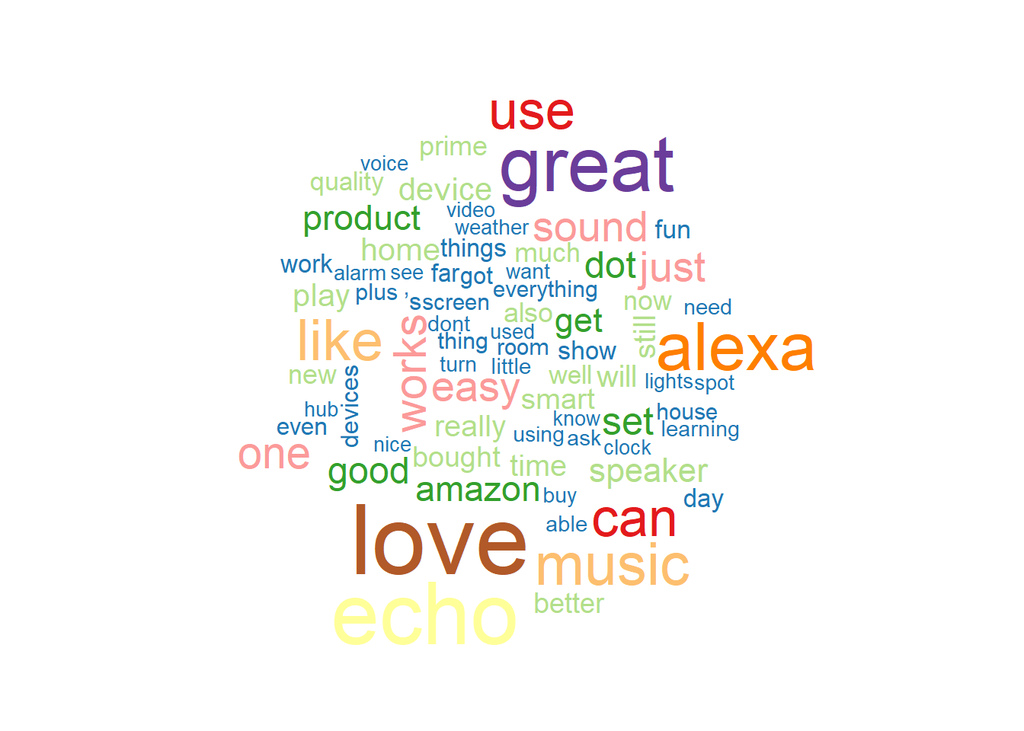

```r
## Enter your code here
freq <- data.frame(sort(colSums(as.matrix(review_dtm)), decreasing=TRUE))
wordcloud(rownames(freq), freq[,1], max.words=75, colors=brewer.pal(12, "Paired"))
```

# Question 4

Remove the less frequent terms such that the sparsity is less than 0.98. And show the result of 10 to 20 rows, 20 to 25 columns.

```r
## Enter your code here
review_dtm <- removeSparseTerms(review_dtm, 0.98)
review_dtm
```

```
## <<DocumentTermMatrix (documents: 3150, terms: 107)>>
## Non-/sparse entries: 16518/320532
## Sparsity           : 95%
## Maximal term length: 10
## Weighting          : term frequency (tf)
```

```r
inspect(review_dtm[10:20, 20:25])
```

```
## <<DocumentTermMatrix (documents: 11, terms: 6)>>
## Non-/sparse entries: 1/65
## Sparsity           : 98%
## Maximal term length: 7
## Weighting          : term frequency (tf)
## Sample             :
##     Terms
## Docs alarm another ask see smart speaker
##   10     0       0   0   0     0       0
##   11     0       0   0   0     0       0
##   12     0       0   0   0     0       0
##   13     0       0   0   0     0       0
##   14     0       0   0   0     0       0
##   15     0       0   0   0     0       0
##   16     0       0   0   0     0       0
##   17     0       0   0   0     0       1
##   18     0       0   0   0     0       0
##   19     0       0   0   0     0       0
```